> Greenhouse Gas Emmision

> -by Ayush Dosajh

========================================================

> Resources -

### http://datasets.wri.org/dataset/cait-country (for data set)

### www.datascience.com

> Data overveiw/ summary

```
##               Country          Year         TotalGHG
##  Afghanistan      :  23   Min.   :1990   Min.   :    0.03
##  Albania          :  23   1st Qu.:1995   1st Qu.:    7.07
##  Algeria          :  23   Median :2001   Median :   26.57
##  Angola           :  23   Mean   :2001   Mean   :  429.35
##  Antigua & Barbuda:  23   3rd Qu.:2007   3rd Qu.:  106.49
##  Argentina        :  23   Max.   :2012   Max.   :44815.54
##  (Other)          :4186                  NA's   :106
##  Total.GHG.land     Total.CO2.land        TotalCH4
##  Min.   : -139.27   Min.   :    0.00   Min.   :   0.003
##  1st Qu.:    8.59   1st Qu.:    1.47   1st Qu.:   2.018
##  Median :   38.81   Median :    9.68   Median :   7.760
##  Mean   :  458.52   Mean   :  314.73   Mean   :  73.520
##  3rd Qu.:  134.98   3rd Qu.:   64.89   3rd Qu.:  28.116
##  Max.   :47598.55   Max.   :33843.05   Max.   :7153.957
##  NA's   :106        NA's   :20         NA's   :104
##     TotalN2O           TotalF.Gas       TotalCO2.land
##  Min.   :   0.0005   Min.   :  0.0000   Min.   : -187.31
##  1st Qu.:   0.5685   1st Qu.:  0.0066   1st Qu.:    4.15
##  Median :   3.7126   Median :  0.0694   Median :   21.77
##  Mean   :  32.0882   Mean   :  5.6466   Mean   :  345.47
##  3rd Qu.:  11.4777   3rd Qu.:  0.5823   3rd Qu.:   87.89
##  Max.   :3045.4223   Max.   :773.1061   Max.   :36421.81
##  NA's   :103                            NA's   :103
##  TotalCH4.land      TotalN2O.land           Energy
##  Min.   :   0.011   Min.   :   0.0005   Min.   :    0.74
##  1st Qu.:   2.636   1st Qu.:   0.7748   1st Qu.:    9.07
##  Median :   8.771   Median :   4.0565   Median :   38.23
##  Mean   :  77.605   Mean   :  33.8027   Mean   :  453.37
##  3rd Qu.:  32.812   3rd Qu.:  12.3669   3rd Qu.:  138.28
##  Max.   :7298.599   Max.   :3105.0351   Max.   :35099.15
##  NA's   :241        NA's   :241         NA's   :1173
##    Industrial         Agriculture           Waste
##  Min.   :   0.0000   Min.   :   0.000   Min.   :   0.0009
##  1st Qu.:   0.0736   1st Qu.:   0.992   1st Qu.:   0.3973
##  Median :   0.7186   Median :   5.961   Median :   1.4539
##  Mean   :  21.7558   Mean   :  56.304   Mean   :  15.7017
##  3rd Qu.:   4.2841   3rd Qu.:  20.393   3rd Qu.:   5.3289
##  Max.   :2839.5779   Max.   :5381.510   Max.   :1495.2879
##  NA's   :164         NA's   :103
##     Land.Use         BunkerFuels      Electricity.Heat   Manufacturing
##  Min.   :-412.227   Min.   :   0.00   Min.   :    0.00   Min.   :   0.00
##  1st Qu.:  -0.623   1st Qu.:   0.24   1st Qu.:    1.79   1st Qu.:   0.98
##  Median :   0.056   Median :   1.00   Median :   11.50   Median :   5.21
##  Mean   :  29.152   Mean   :  15.74   Mean   :  181.95   Mean   :  81.64
##  3rd Qu.:  11.289   3rd Qu.:   4.05   3rd Qu.:   43.05   3rd Qu.:  28.89
##  Max.   :3513.469   Max.   :1133.07   Max.   :14903.97   Max.   :6456.80
##  NA's   :103        NA's   :1173      NA's   :1173       NA's   :1173
##  Transportation      OtherFuel        FugitiveEmissions
##  Min.   :   0.04   Min.   :   0.025   Min.   :   0.0000
##  1st Qu.:   1.87   1st Qu.:   1.640   1st Qu.:   0.0000
##  Median :   5.72   Median :   5.401   Median :   0.2498
##  Mean   :  90.52   Mean   :  66.703   Mean   :  24.1617
##  3rd Qu.:  23.67   3rd Qu.:  17.974   3rd Qu.:   5.1150
##  Max.   :7186.97   Max.   :4010.940   Max.   :2569.6874
##  NA's   :1173      NA's   :1173       NA's   :64
```

> CAIT data set of global Green house gas emmision is acquired from - http://datasets.wri.org/dataset/cait-country .The CAIT Country GHG emissions collection applies a consistent methodology to create a six-gas, multi-sector, and internationally comparable data set for 186 countries.

> DATA names with its Units “Country” -Name of the countries  
> “Year”- year The data is for  
> “TotalGHG”- in Metric Tonnes  
> “Total.GHG.land”- in Metric Tonnes  
> “Total.CO2.land”- in Metric Tonnes  
> “TotalCH4”- in Metric Tonnes  
> “TotalN2O”- in Metric Tonnes  
> “TotalF.Gas”- in Metric Tonnes  
> “TotalCO2.land”- in Metric Tonnes  
> “TotalCH4.land”- in Metric Tonnes  
> “TotalN2O.land”- in Metric Tonnes  
> “Energy”- in Metric Tonnes  
> “Industrial”- in Metric Tonnes  
> “Agriculture”- in Metric Tonnes  
> “Waste”- in Metric Tonnes  
> “Land.Use” - in Metric Tonnes  
> “BunkerFuels”- in Metric Tonnes  
> “Electricity.Heat” - in Metric Tonnes “Manufacturing”- in Metric Tonnes  
> “Transportation”- in Metric Tonnes  
> “OtherFuel”- in Metric Tonnes  
> “FugitiveEmissions”- in Metric Tonnes

# Univariate Plots Section

> All the univariate plots are here.

A simple histogram dipicting TotalGHG distribution (it shows that most of the countries over the year has very less emmision also that there are more emission by certain coutries over the year other than this not much can be drawn out)

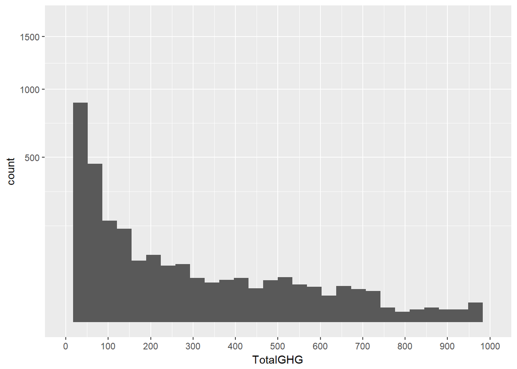

produces histograms of count(here no. countries with GHG Emmision for each year seperatly)

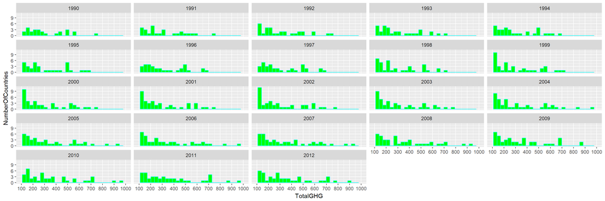

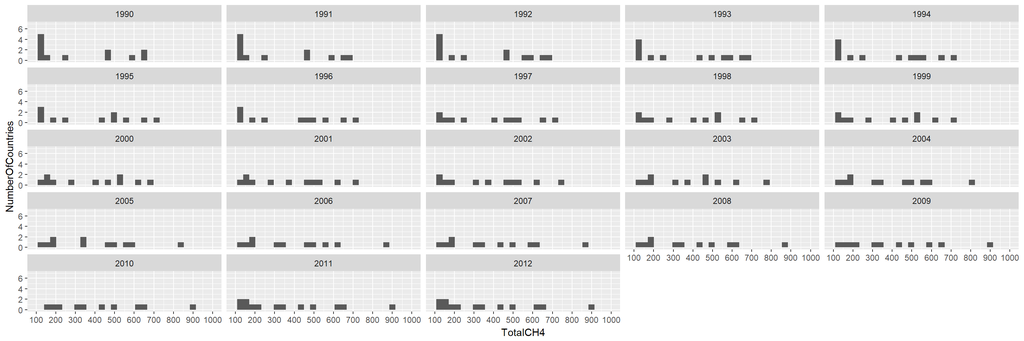

log trans to check for normal distribution

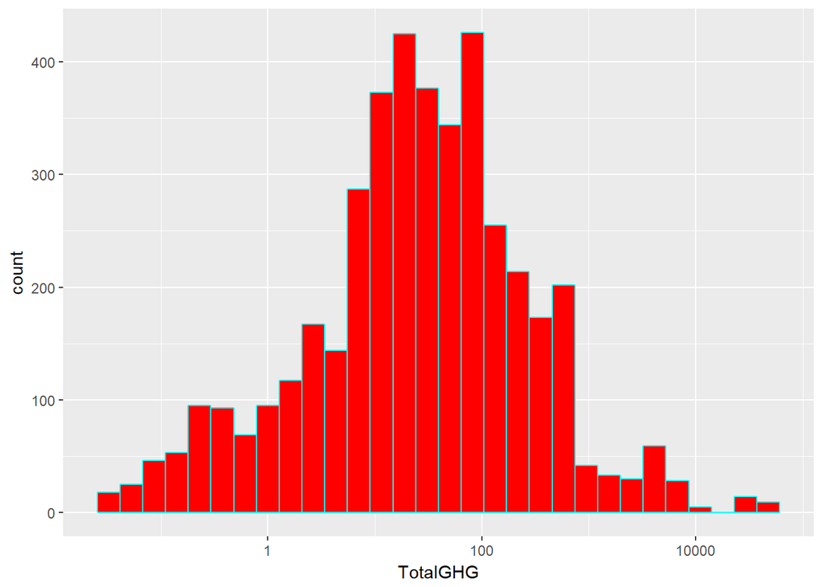

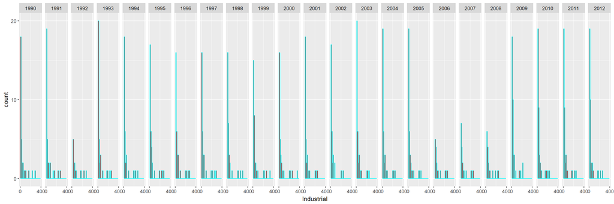

GHG PRODUCTION FROM DIFFRENT SOURCES and plotting side by side using grid arrange

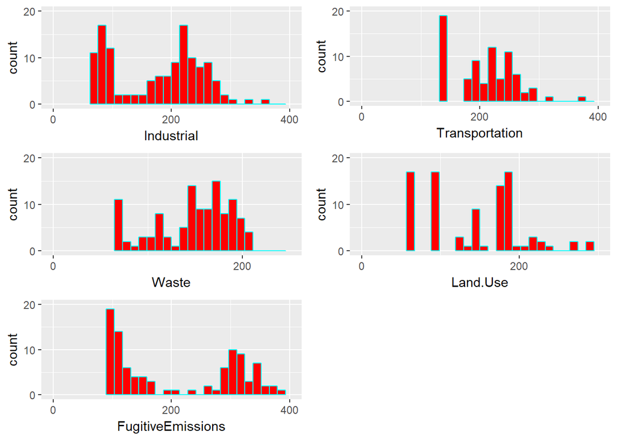

> Univariate Findings

# Univariate Analysis

### What is the structure of your dataset?

The data set contains 4324 obs over 22 variables . Dataset gives info of major green house gasses and thier sources .

### What is/are the main feature(s) of interest in your dataset?

The sources as well as the the total emmisions are given and hence contribution of each sector on total emmision.

### What other features in the dataset do you think will help support your into your feature(s) of interest?

Distribution of data over the years . or groping them by countries / continents to compare distributions.

### Of the features you investigated, were there any unusual distributions? Did you perform any operations on the data to tidy, adjust, or change the form of the data? If so, why did you do this?

No changes were done to the data as it was clean and ready to use

# Bivariate Plots Section

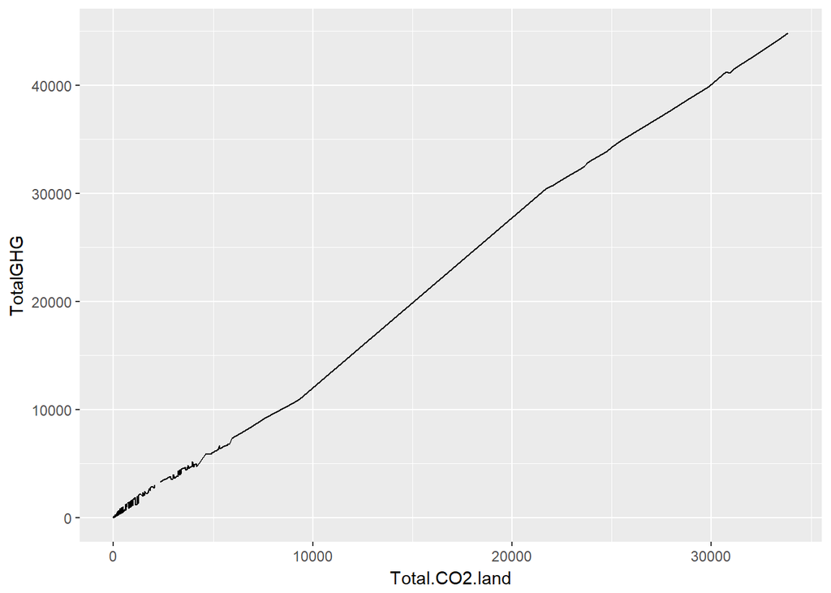

ggpairs of selected country data only to display scatterplot matrix

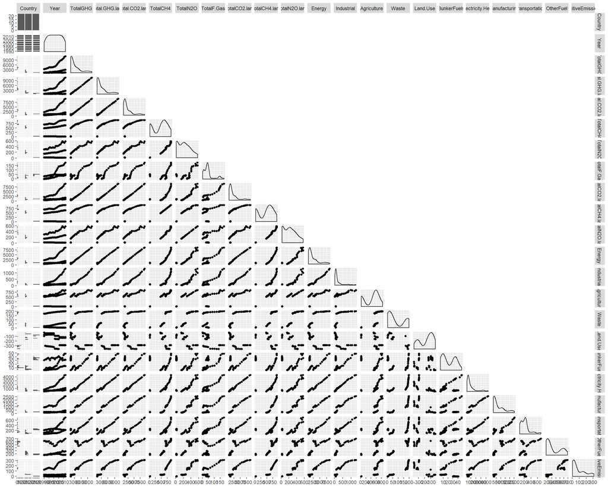

Almost linear relation ship between land + CH4 emmision and CH4 emmision but still there are some instances where CH4+ land is more than CH4

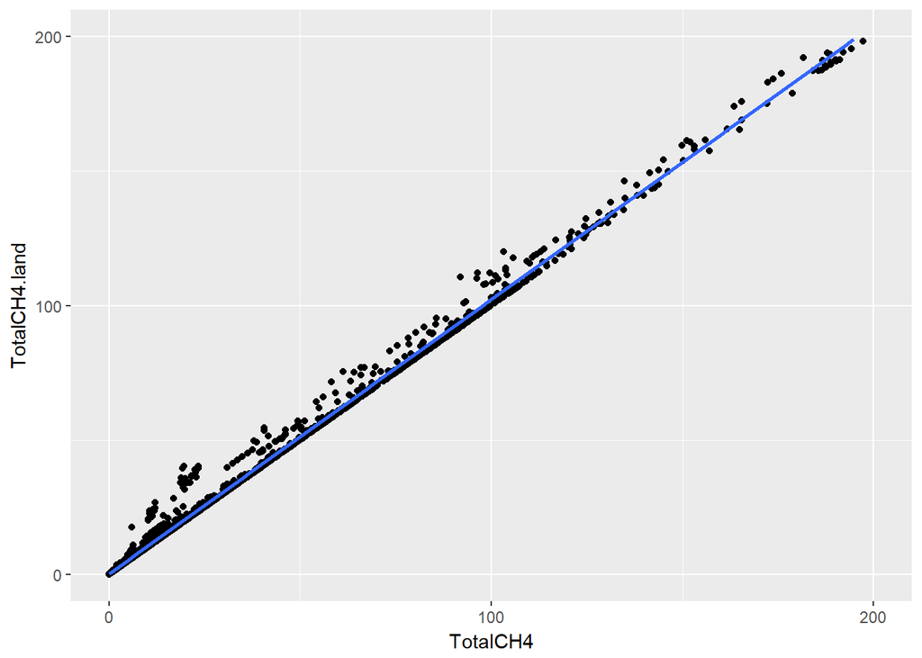

For most part japan’s Emmision due to energy production is 1000 which is far lower to China which Goes as far as about 9,000 Metric tonnes !!!!

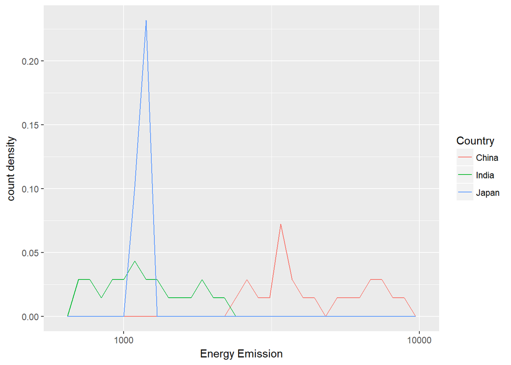

```
##         Country        Year         TotalGHG     Total.GHG.land
##  China      :23   Min.   :1990   Min.   : 1190   Min.   : 1068
##  India      :23   1st Qu.:1995   1st Qu.: 1313   1st Qu.: 1224
##  Japan      :23   Median :2001   Median : 1801   Median : 1670
##  Afghanistan: 0   Mean   :2001   Mean   : 3111   Mean   : 2942
##  Albania    : 0   3rd Qu.:2007   3rd Qu.: 4337   3rd Qu.: 4019
##  Algeria    : 0   Max.   :2012   Max.   :10975   Max.   :10684
##  (Other)    : 0
##  Total.CO2.land      TotalCH4         TotalN2O        TotalF.Gas
##  Min.   : 614.9   Min.   : 21.87   Min.   : 19.14   Min.   :  2.56
##  1st Qu.:1115.4   1st Qu.: 31.58   1st Qu.: 27.26   1st Qu.: 19.36
##  Median :1234.7   Median :530.39   Median :194.89   Median : 40.04
##  Mean   :2403.8   Mean   :446.36   Mean   :211.09   Mean   : 49.43
##  3rd Qu.:3258.8   3rd Qu.:698.65   3rd Qu.:349.23   3rd Qu.: 49.30
##  Max.   :9312.5   Max.   :914.00   Max.   :572.44   Max.   :182.31
##
##  TotalCO2.land    TotalCH4.land    TotalN2O.land        Energy
##  Min.   : 586.3   Min.   : 21.87   Min.   : 19.14   Min.   : 685.4
##  1st Qu.:1033.4   1st Qu.: 31.59   1st Qu.: 27.27   1st Qu.:1129.1
##  Median :1129.7   Median :530.50   Median :195.71   Median :1219.7
##  Mean   :2234.2   Mean   :446.96   Mean   :211.41   Mean   :2377.6
##  3rd Qu.:2939.9   3rd Qu.:699.51   3rd Qu.:349.71   3rd Qu.:3297.2
##  Max.   :9020.8   Max.   :914.33   Max.   :573.11   Max.   :8649.8
##
##    Industrial       Agriculture         Waste            Land.Use
##  Min.   :  29.53   Min.   : 23.92   Min.   :  4.563   Min.   :-370.98
##  1st Qu.:  82.19   1st Qu.: 29.15   1st Qu.:  9.035   1st Qu.:-291.67
##  Median :  96.37   Median :546.76   Median : 40.624   Median :-127.41
##  Mean   : 237.29   Mean   :418.29   Mean   : 77.515   Mean   :-168.66
##  3rd Qu.: 254.31   3rd Qu.:616.12   3rd Qu.:177.511   3rd Qu.: -74.31
##  Max.   :1296.55   Max.   :844.54   Max.   :197.602   Max.   : -27.04
##
##   BunkerFuels    Electricity.Heat Manufacturing    Transportation
##  Min.   : 4.81   Min.   : 257.1   Min.   : 171.6   Min.   : 64.54
##  1st Qu.: 9.70   1st Qu.: 458.4   1st Qu.: 239.7   1st Qu.:116.18
##  Median :16.24   Median : 579.2   Median : 267.0   Median :216.23
##  Mean   :21.65   Mean   :1073.1   Mean   : 675.5   Mean   :223.85
##  3rd Qu.:34.52   3rd Qu.:1169.8   3rd Qu.:1116.4   3rd Qu.:255.68
##  Max.   :47.84   Max.   :4404.9   Max.   :2546.1   Max.   :702.91
##
##    OtherFuel     FugitiveEmissions
##  Min.   :159.1   Min.   :  2.705
##  1st Qu.:184.0   1st Qu.:  3.627
##  Median :212.1   Median : 32.750
##  Mean   :324.5   Mean   : 80.680
##  3rd Qu.:522.3   3rd Qu.:148.683
##  Max.   :686.0   Max.   :309.928
##
```

Relationship between land + CO2 emmision and CO2 emmision is more varied though a bit of linear trend could be seen but it is not as linear as CH4 or N2O but rather it more spread around mean

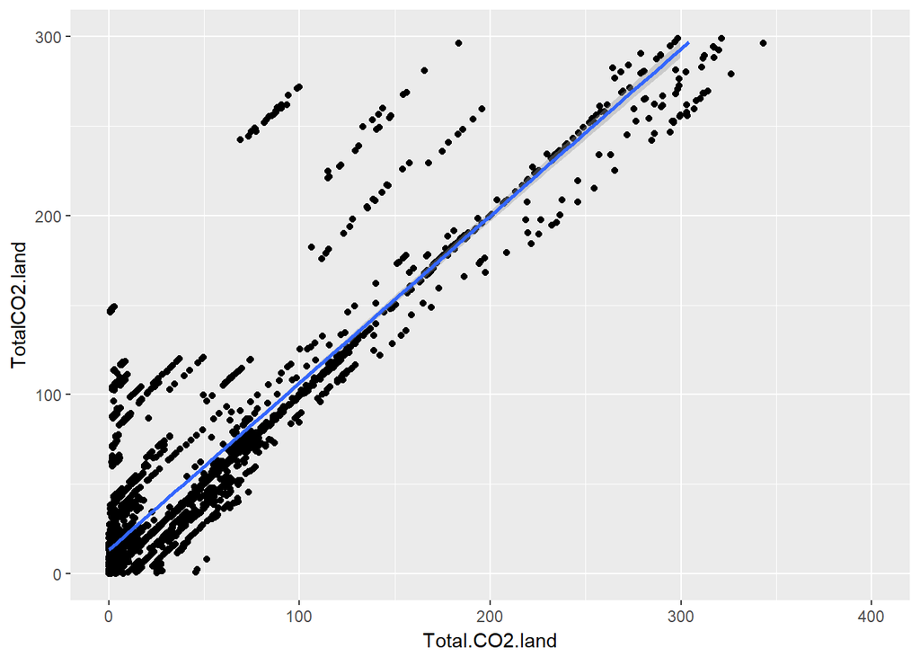

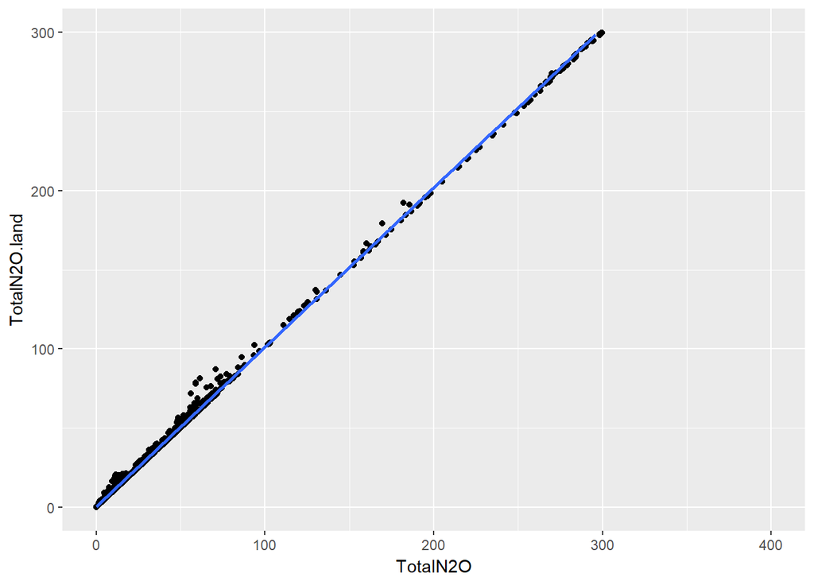

# Bivariate Analysis

> Summarization - The variable are highly co-related and shows linear trend which is to be expected as all the date is about ghgs hence Year vs variable plots are taken up for analysis to produce meaningful plots

### Talk about some of the relationships you observed in this part of the . How did the feature(s) of interest vary with other features in dataset?

The features like Industrial emmision , Agriculture Emmision tend to increase over the years not much seasonality is seen the trend of emission of most variables are on the increasing side along the years.

### Did you observe any interesting relationships between the other features (not the main feature(s) of interest)?

Relationship between land + CO2 emmision and CO2 emmision is more varied though a bit of linear trend could be seen but it is not as linear as CH4 Also N20 too doesnot show much daviation this could be either because Co2 has varied sources that effects its emmision and though land does effect Co2 but the effect is not purely linear .

### What was the strongest relationship you found?

Most of relation ships are strong as the whole data set has data of Green house gasses

# Multivariate Plots Section

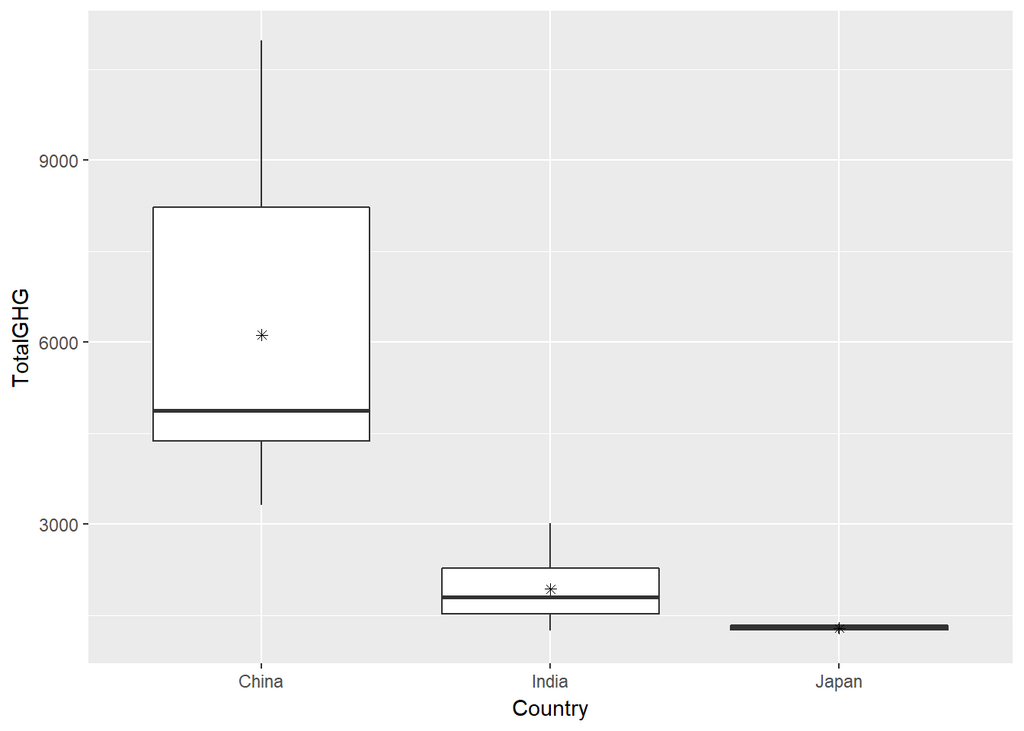

```
##
## (1990,1995] (1995,2000] (2000,2005] (2005,2012]        <NA>
##          15          15          15          21           3
```

```
##
## (1990,1992] (1992,1994] (1994,1996] (1996,1998] (1998,2000] (2000,2002]
##           6           6           6           6           6           6
## (2002,2004] (2004,2006] (2006,2008] (2008,2010] (2010,2012]        <NA>
##           6           6           6           6           6           3
```

The graph display huge disparity b/w some of the observation (countries)

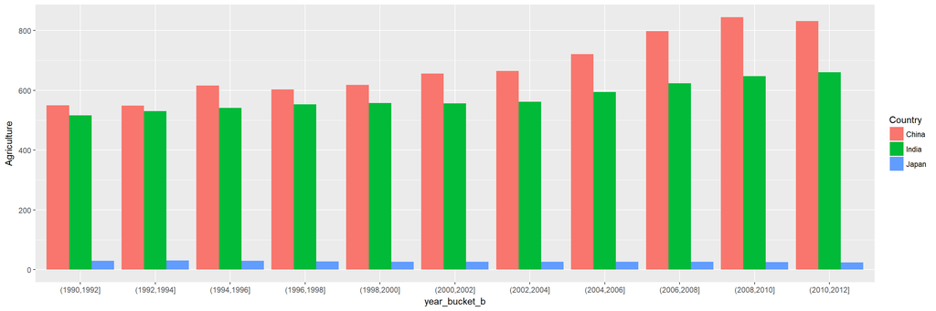

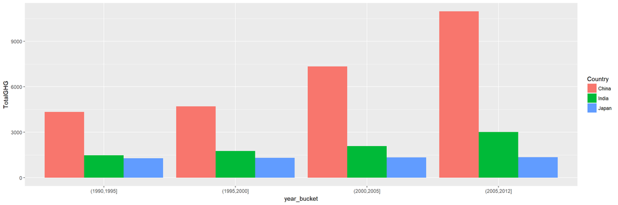

Emmision produced by countries the trend is increasing also ,Japan Emmsions are less in comparison to China or india .

China Again is the major poluter followed by India and japan which is very low in comparison . Normally All the trends follow an increasing pattern but N20 production by china around 2010 showed a moderate decrese which is very rare for this data set, This could be due to external reasons

PLOTTING ALL THE GASSES COUNTRY WISE USING GRIDEXTRA.gridarrange

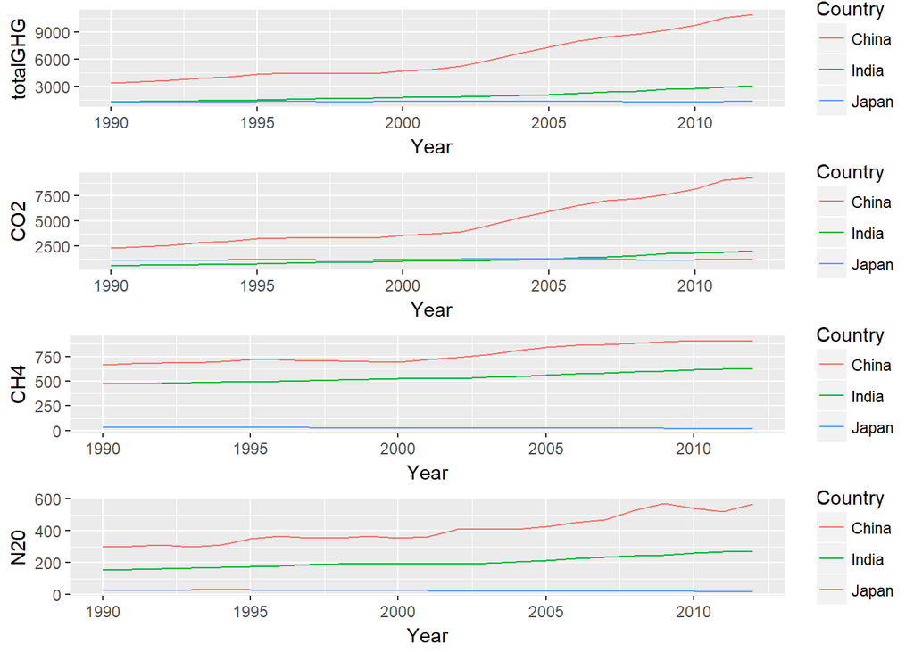

PLOTTING ALL THE indutry emmision COUNTRY WISE USING GRIDEXTRA.gridarrange The plot dipicts the trend followed by some of the countries over the years in diffrent fields

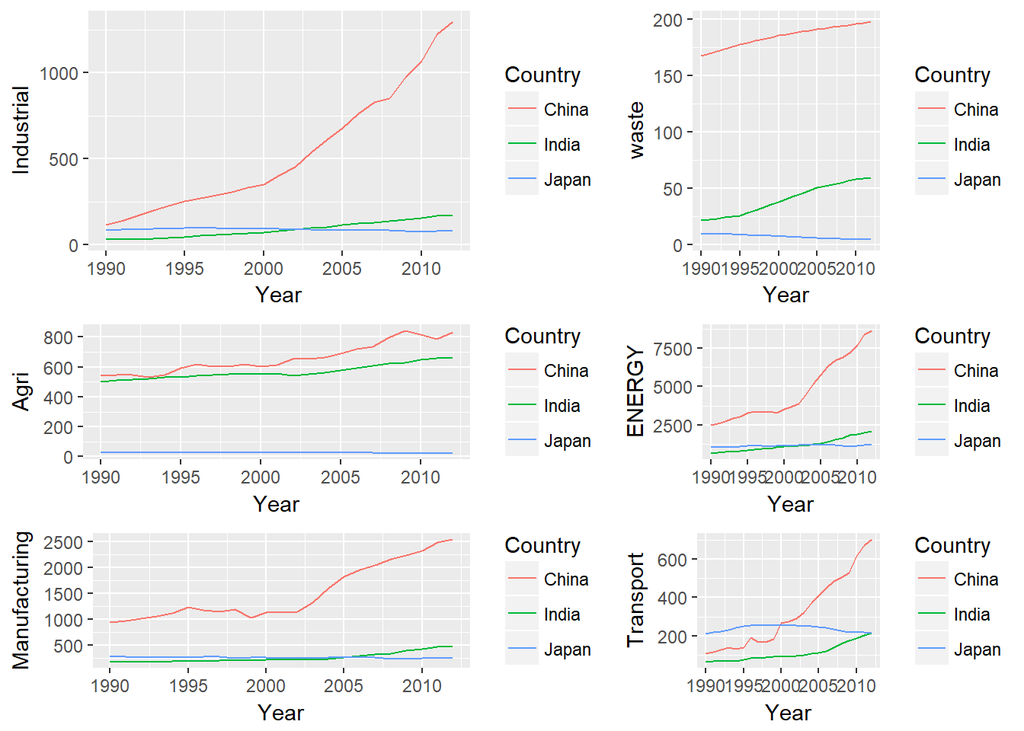

Heat map

```
##        1                  2                   3
##  Min.   :    0.74   Min.   :   0.0000   Min.   :   0.000
##  1st Qu.:    9.07   1st Qu.:   0.0736   1st Qu.:   0.992
##  Median :   38.23   Median :   0.7186   Median :   5.961
##  Mean   :  453.37   Mean   :  21.7558   Mean   :  56.304
##  3rd Qu.:  138.28   3rd Qu.:   4.2841   3rd Qu.:  20.393
##  Max.   :35099.15   Max.   :2839.5779   Max.   :5381.510
##  NA's   :1173       NA's   :164         NA's   :103
##        4                   5                  6
##  Min.   :   0.0009   Min.   :-412.227   Min.   :    0.00
##  1st Qu.:   0.3973   1st Qu.:  -0.623   1st Qu.:    1.79
##  Median :   1.4539   Median :   0.056   Median :   11.50
##  Mean   :  15.7017   Mean   :  29.152   Mean   :  181.95
##  3rd Qu.:   5.3289   3rd Qu.:  11.289   3rd Qu.:   43.05
##  Max.   :1495.2879   Max.   :3513.469   Max.   :14903.97
##                      NA's   :103        NA's   :1173
##        7                 8                 9
##  Min.   :   0.00   Min.   :   0.04   Min.   :   0.0000
##  1st Qu.:   0.98   1st Qu.:   1.87   1st Qu.:   0.0000
##  Median :   5.21   Median :   5.72   Median :   0.2498
##  Mean   :  81.64   Mean   :  90.52   Mean   :  24.1617
##  3rd Qu.:  28.89   3rd Qu.:  23.67   3rd Qu.:   5.1150
##  Max.   :6456.80   Max.   :7186.97   Max.   :2569.6874
##  NA's   :1173      NA's   :1173      NA's   :64
```

```
## [1] 4324    9
```

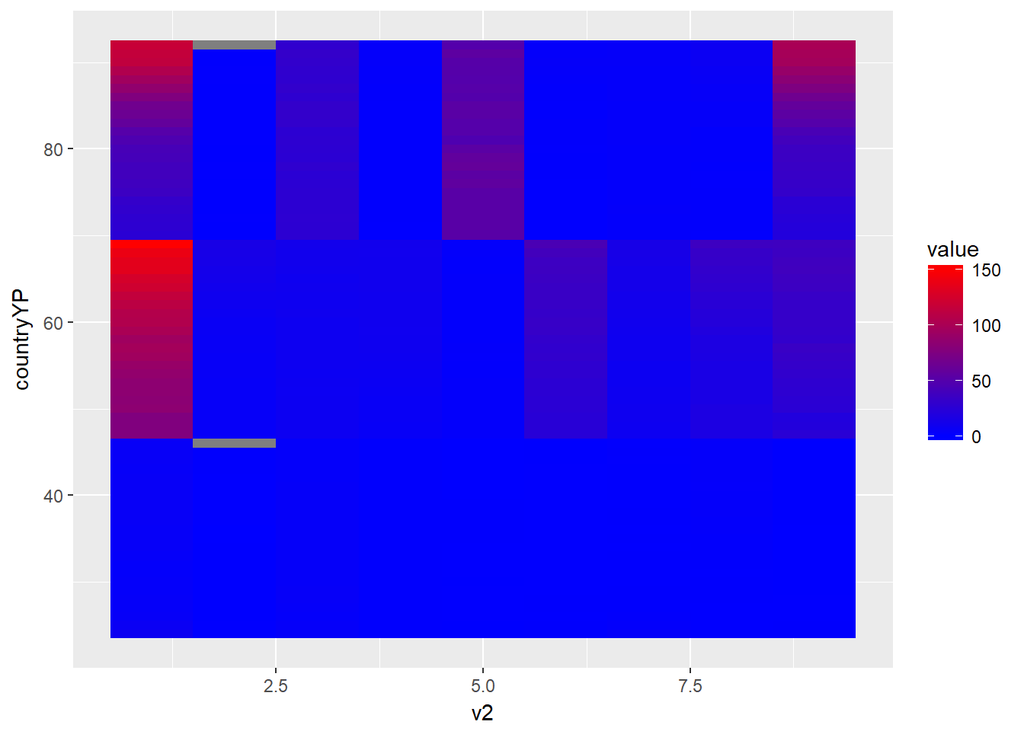

# Multivariate Analysis

### Talk about some of the relationships you observed in this part of the . Were there features that strengthened each other in terms of at your feature(s) of interest?

China is mostly at the top for most variables / Analysis for emmision of variables . The trend is in the Increasing direction mostly but Japan is showing a decreasing trend over the years this might be due to technogical advancements or better management

### Were there any interesting or surprising interactions between features?

Green house gas emmision is a global phenomenon and the presence of green house gasses produced by industries are increasing in many cases this was true as in cases of India and China but japan showed signs of decres too in certain sectors.

# MODELING USING ARIMA MODEL

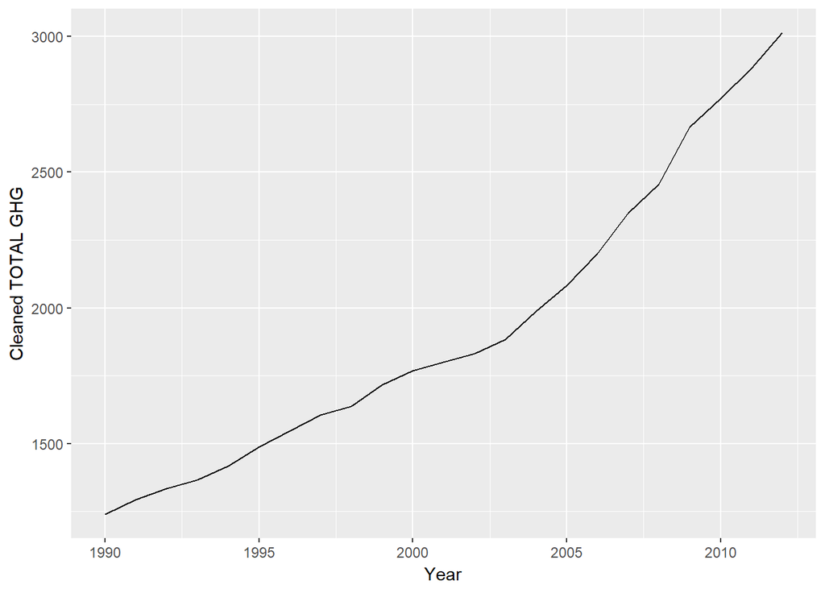

Calculating moving averages and ploting it

```
##        V1
##  Min.   :1330
##  1st Qu.:1568
##  Median :1800
##  Mean   :1893
##  3rd Qu.:2158
##  Max.   :2758
##  NA's   :4
```

```
##        V1
##  Min.   :1490
##  1st Qu.:1643
##  Median :1819
##  Mean   :1864
##  3rd Qu.:2055
##  Max.   :2370
##  NA's   :10
```

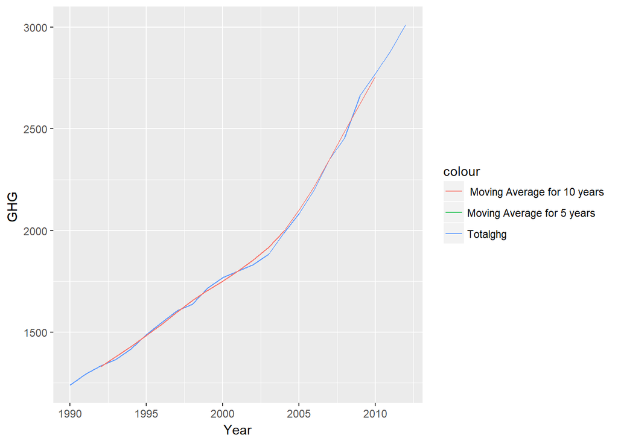

Not much variation is seen here

DECOMPOSITION

TREND THE GHG emmision follows a increasing pattern overtime

Seasonality yearly data no seasonality here

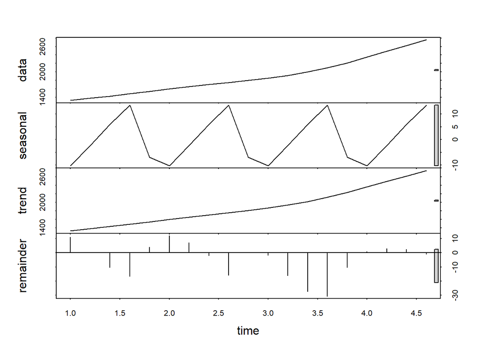

```r
tghg_ma <- ts(na.omit(subt$ghg_ma5), frequency=5)
#taking 5 years as a frequeny and will build model around it

decomp = stl(tghg_ma, s.window="periodic" ,)
deseasonal_ghg <- seasadj(decomp)
plot(decomp)
```

```r
#trend could easily be seen almost not too much noise


#Arima model requires a stationary series

adf.test(tghg_ma, alternative = "stationary")
```

```
##
##  Augmented Dickey-Fuller Test
##
## data:  tghg_ma
## Dickey-Fuller = -1.1467, Lag order = 2, p-value = 0.8974
## alternative hypothesis: stationary
```

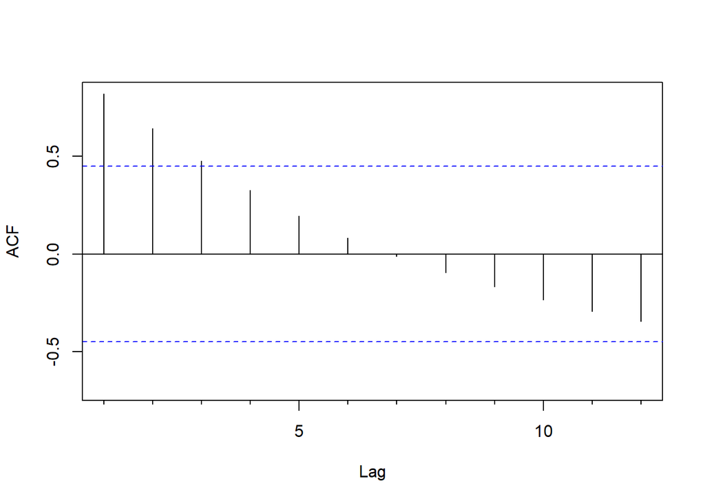

```r
#Autocorrelation plots for chosing Arima parametres

Acf(tghg_ma, main='')
```

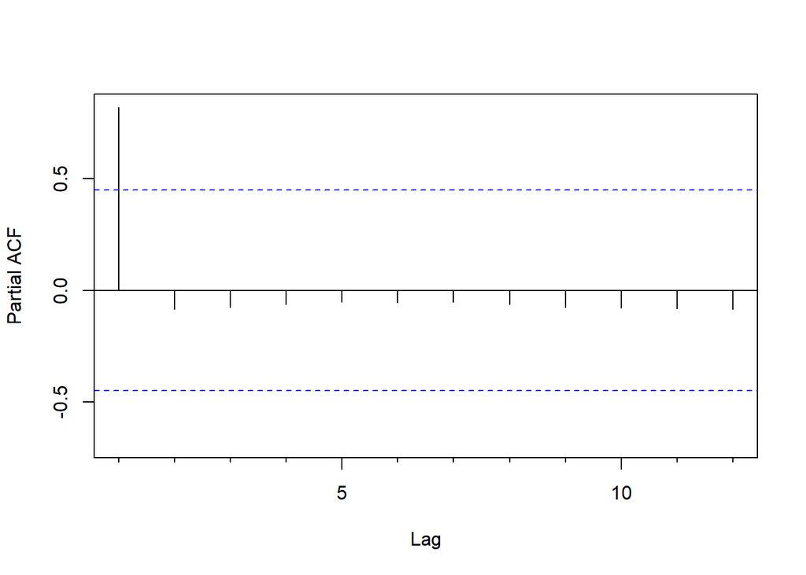

```r
Pacf(tghg_ma, main='')
```

Creating models to find best fit

```r
m1 <- auto.arima(deseasonal_ghg, seasonal=FALSE)
m1
```

```
## Series: deseasonal_ghg
## ARIMA(0,2,0)
##
## sigma^2 estimated as 284.3:  log likelihood=-72.14
## AIC=146.28   AICc=146.55   BIC=147.11
```

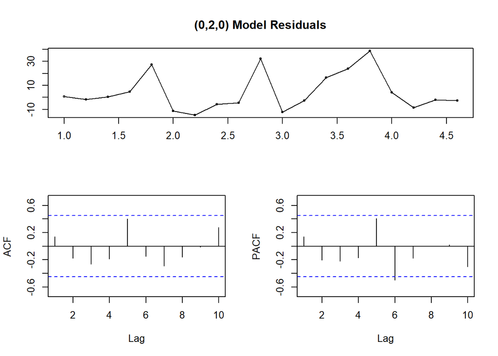

```r
#model is ok because no major corelation can be seen from ACF andPACF checking for '6'
tsdisplay(residuals(m1), lag.max=10, main='(0,2,0) Model Residuals')
```

```r
m2 <- arima(deseasonal_ghg, order=c(1,1,6))

m2
```

```
##
## Call:
## arima(x = deseasonal_ghg, order = c(1, 1, 6))
##
## Coefficients:
##          ar1     ma1     ma2     ma3     ma4     ma5     ma6
##       0.8541  0.6089  0.4721  0.5277  0.3786  1.0878  0.3738
## s.e.  0.1110  0.4077  0.3277  0.3789  0.4330  0.5022  0.4005
##
## sigma^2 estimated as 110.3:  log likelihood = -73.57,  aic = 163.15
```

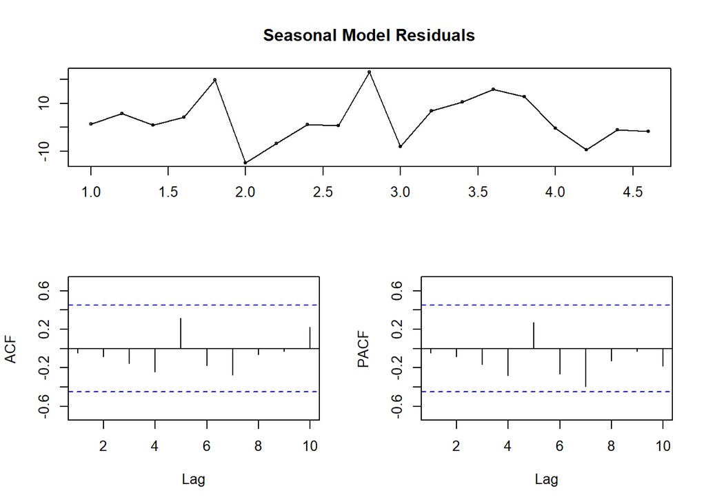

```r
tsdisplay(residuals(m2), lag.max=10, main='Seasonal Model Residuals')
```